# Activité 5 - Analyse multivariée, imputation et valeurs aberrantes

Andrés Silva

26/03/2020

**Objectifs de l’activité** :

- Imputer les valeurs manquantes
- Retirer les données aberrantes
- Effectuer une analyse discriminante linéaire ***

Tout d’abord, il faut charger les modules nécessaires pour le développement de l’activité. Les modules utilisés sont :

- `tidyverse` sera utilisé pour manipuler et effectuer des opérations sur les tableaux
- Le module `VIM` permet d’afficher la structure des données manquantes.
- L’imputation des données manquantes est fait avec le module `mice`.
- Le module `mvoutlier` sert à détecter les données aberrantes.
- L’analyse discriminante se fait avec le module `ade4`

La fonction `read_csv()` sert à lire le fichier contenant les données, lesquels sont stockées dans le tableau *data_dragon*.

```r
library(tidyverse)
library(VIM)
library(mice)
library(mvoutlier)
library(ade4)

set.seed(197273)
data_dragon <- read_csv("data/dragons.csv")
```

# 1. *Imputation de données manquantes*

La visualisation des données manquantes peut être faite avec la fonction `matrixplot()` du module `VIM`. En autre, la fonction `aggr()` (module `VIM`) permet visualiser la proportion de données manquantes par chacune des variables (segments) mesurées.

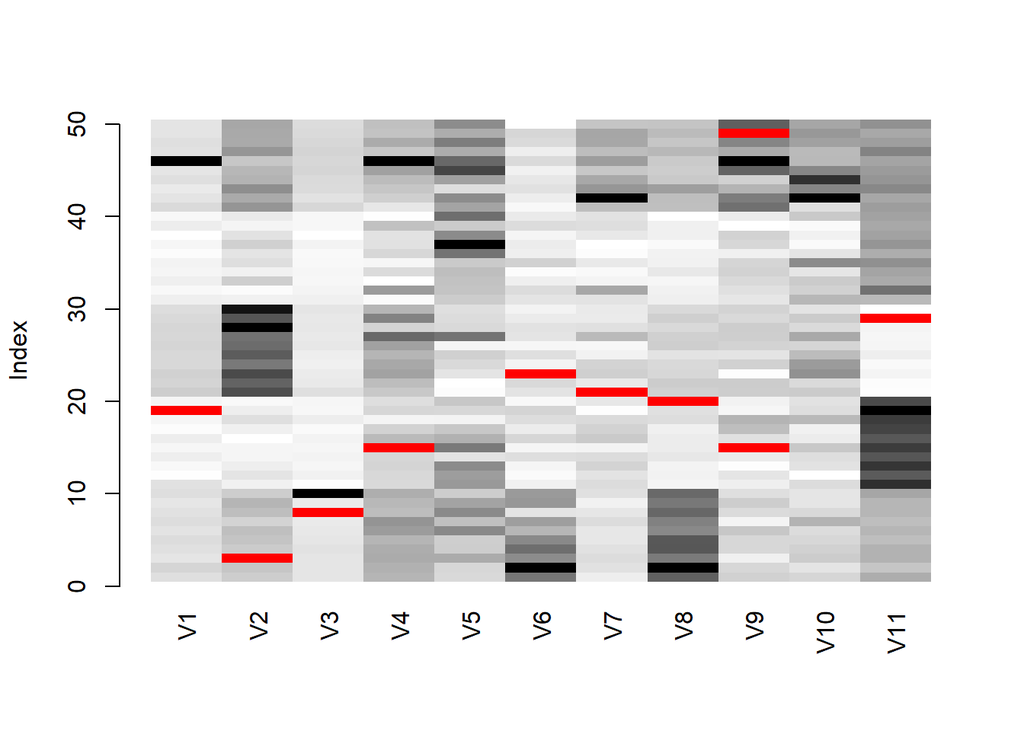

```r
matrixplot(data_dragon %>%
             select(-c(ID, Species)))
```

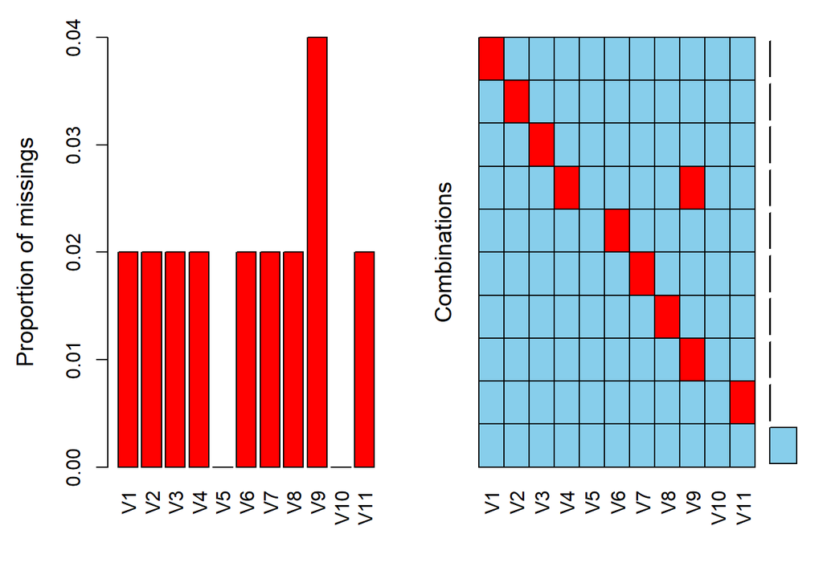

```r
#plot(aggr(data_dragon %>%
 #           select(-c(ID, Species))))
aggr(data_dragon %>%
        select(-c(ID, Species)))
```

En regardant les graphiques obtenus, il est évident que les seules variables qui n’ont pas de données manquantes sont *V5* et *V10*, tandis que la variable *V9* a la proportion la plus haute de données manquantes (2). La proportion des observations avec données manquantes par rapport au total d’observations est calculée avec les commandes du code ci-dessous.

```r
row_missing <- data_dragon %>%
  filter(apply(., 1, function(x) any(is.na(x))))

nrow(row_missing) / nrow(data_dragon)
```

```
## [1] 0.18
```

9 (18 %) des 50 individus ont au moins une donnée manquante. La fonction `mice()` fait l’imputation des données manquantes, cette fonction prend le tableau avec les données et utilise une méthode d’imputation choisie par l’utilisateur, dans ce cas la méthode **random forest** a été choisie. La fonction `complete()` remplace les données manquantes du tableau original par les données calculées par la fonction `mice()`. Finalement, un graphique est fait avec la fonction `matrixplot()` afin de confirmer que toutes les données manquantes ont été imputées (pas de lignes rouges). La fonction `set.seed()` sert à fixer les nombres aléatoires générés pendant le développement de l’activité, afin d’éviter des changements dans les résultats des futures exécutions du code et de rendre le code reproductible.

```r
set.seed(197273)
dragons_mice <- mice(data_dragon %>%
                       select(-ID), method = "rf")
```

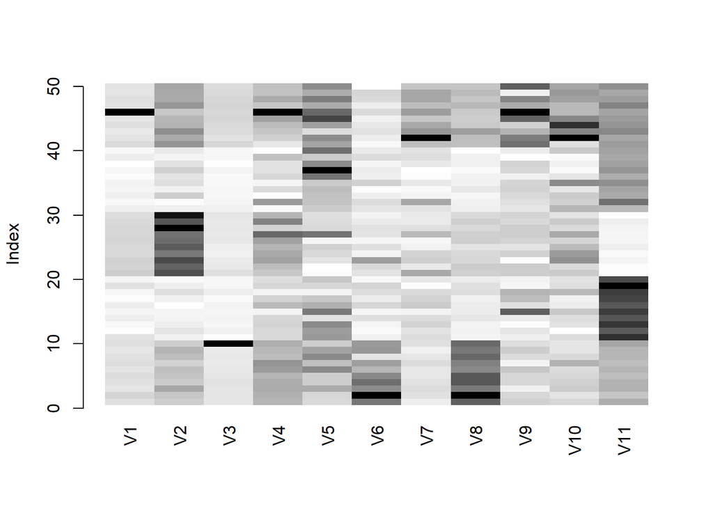

```r
dragons_imp <- complete(dragons_mice)
dragons_imp <- cbind("ID" = data_dragon$ID, dragons_imp)
matrixplot(dragons_imp %>%
             select(-ID, -Species))
```

Une fois l’attribution des données terminée, la détection de données anormales peut être effectuée.

# 2. *Détection et élimination des données aberrantes*

Le boxplot est une technique univariée utile pour montrer un premier aperçu des données aberrantes. Les boxplot des différentes variables montrent que *V1* et *V3* ont toutes deux une valeur aberrante dont la valeur est proche de 15. *V7* semble avoir une valeur anormale d’environ 5. Dans le cas de *V4*, *V6*, *V9*, *V10* et *V11*, il existe apparemment des valeurs aberrantes, mais ces cas sont moins évidents.

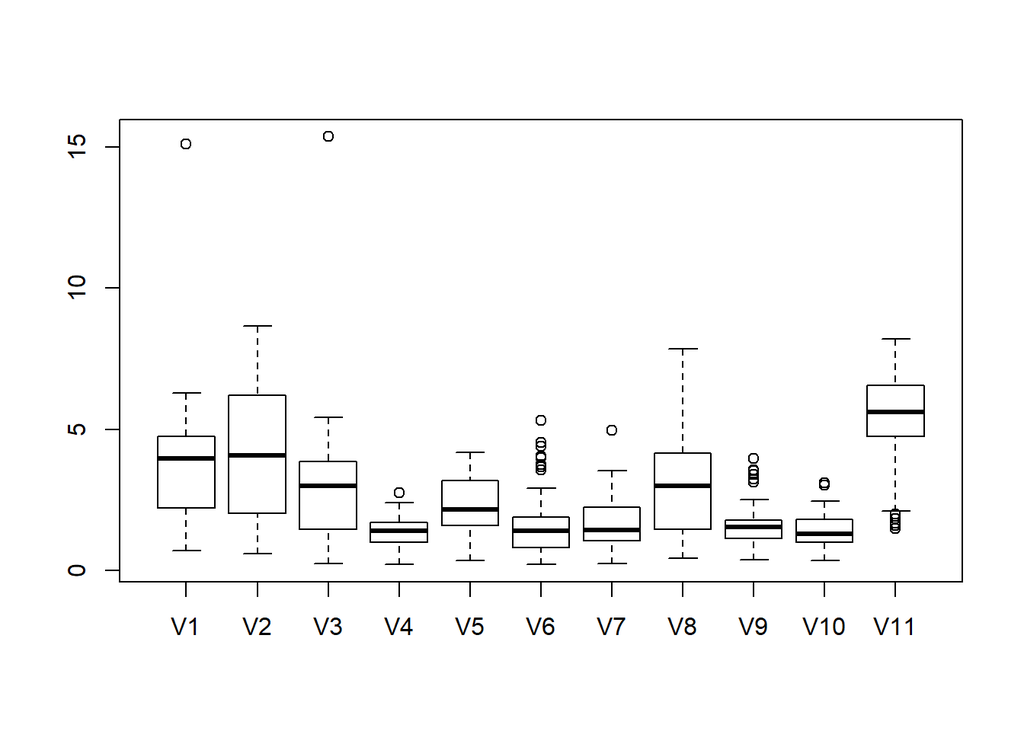

```r
boxplot(dragons_imp %>%
          select(-ID, -Species))
```

Dans le but d’avoir une meilleure estimation des valeurs aberrantes, une méthode multivariée de détection par projection a été employée. Les données anormales sont trouvées avec la fonction `sign2()` du module `mvoutlier`, laquelle les détecte avec un seuil du $\chi^2_{\ df\ =\ 11;\ 0.975}$. Cette fonction produit un vecteur `wfinal01` lequel contient des zéros (individu avec un potentielle donnée anormale) et des uns (individu sans valeurs anormales). Étant donnée qu’il peut y avoir des différences entre les espèces, la détection de valeurs aberrantes est faite en regroupant les données par espèce, cela vise à garantir plus de précision dans cette opération.

```r
niveau <- levels(factor(data_dragon$Species))
row_out <- c()

for (k in niveau) {
  out_temp <- sign2(dragons_imp %>%
                      filter(Species == k) %>%
                      select(-ID, -Species), qcrit = 0.975)$wfinal01
  row_out <- append(row_out, out_temp)
}
```

Le graphique des données anormales est présenté ci-dessous, les points rouges représentent les valeurs aberrantes trouvées par la fonction `sign2`. Étant donné que le nombre de variables est élevé (11 segments), il peut être déroutant de les observer toutes sur un seul graphique de données aberrantes (fonction de base `plot()`). Une application très simple a été développée par l’auteur, elle permet à l’utilisateur de choisir le nombre de variables à montrer et de filtrer les graphiques de valeurs aberrantes par espèce. L’application a été créée comme un exercice d’apprentissage du module `shiny`, et peut être utilisée en allant sur https://afsilvad.shinyapps.io/app_test2/ ou en exécutant la ligne de code `shiny::runGitHub( "Activity5", "afsilvad", subdir = "/app_outDragon")` dans la console R.

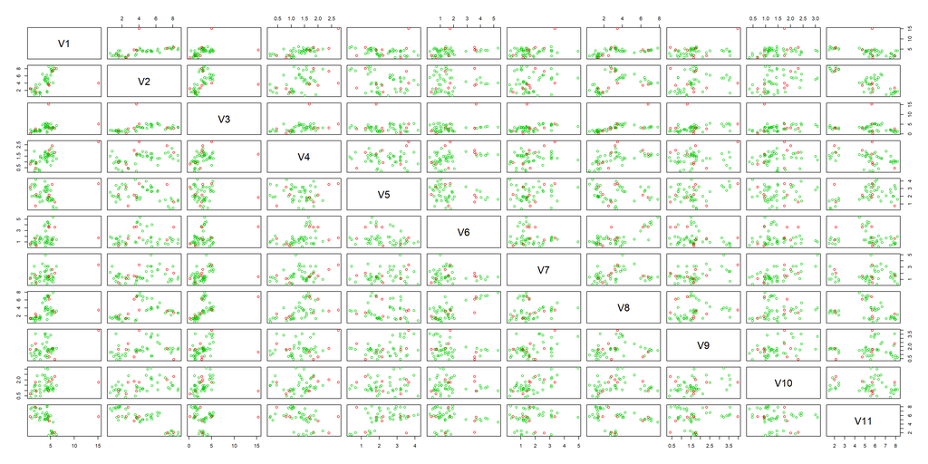

Bien que les graphiques montrent les 8 données aberrantes trouvées, il n’est pas clair à quels individus et à quelles variables elles appartiennent. Les individus contenant les données aberrantes peuvent être identifiées en utilisant la fonction `which()` (tableau 1).

```r
df_out <- dragons_imp[which(row_out == 0), ]
knitr::kable(df_out, format = "html", align = 'c', escape = F,
             caption = "Tableau 1. Individus avec données aberrantes") %>%
   kable_styling(bootstrap_options = c("striped", "hover"), full_width = F,
                 position = "center")
```

Tableau 1. Individus avec données aberrantes

|  | ID | Species | V1 | V2 | V3 | V4 | V5 | V6 | V7 | V8 | V9 | V10 | V11 |
| --- | --- | --- | --- | --- | --- | --- | --- | --- | --- | --- | --- | --- | --- |
| 7 | 7 | Dragon A | 4.70 | 3.41 | 2.92 | 2.00 | 2.17 | 3.57 | 1.58 | 6.22 | 0.70 | 1.86 | 4.74 |
| 10 | 10 | Dragon A | 4.59 | 3.70 | 15.36 | 1.68 | 1.84 | 3.68 | 1.44 | 6.80 | 1.31 | 0.95 | 5.65 |
| 18 | 18 | Dragon B | 1.85 | 2.70 | 2.54 | 0.46 | 0.75 | 1.61 | 1.65 | 2.49 | 2.33 | 1.76 | 7.90 |
| 23 | 23 | Dragon C | 5.90 | 8.09 | 2.82 | 1.83 | 1.23 | 3.57 | 2.01 | 2.81 | 0.42 | 2.31 | 2.14 |
| 27 | 27 | Dragon C | 5.34 | 7.31 | 3.04 | 2.40 | 3.53 | 1.37 | 2.62 | 3.20 | 1.75 | 2.01 | 1.99 |
| 34 | 34 | Dragon D | 1.99 | 1.57 | 1.42 | 0.95 | 2.22 | 0.33 | 0.46 | 1.88 | 1.65 | 0.93 | 5.72 |
| 38 | 38 | Dragon D | 0.70 | 2.49 | 0.23 | 0.81 | 3.20 | 0.67 | 1.15 | 1.40 | 1.64 | 0.68 | 5.76 |
| 46 | 46 | Dragon E | 15.11 | 4.02 | 5.04 | 2.75 | 3.65 | 1.75 | 3.35 | 3.47 | 3.97 | 1.76 | 5.71 |

L’espèce *Dragon A* a deux individus avec données aberrantes, le 7 et le 10. La donnée aberrante de l’individu 7 est l’observation de la variable *V10* (1.86) laquelle est élevée par rapport aux autres observations de cette variable. La valeur de la variable *V3* (15.36) de l’individu 10 est très éloignée des autres neuf observations de cette variable.

Individus de l’espèce Dragon A

| ID | Species | V1 | V2 | V3 | V4 | V5 | V6 | V7 | V8 | V9 | V10 | V11 |
| --- | --- | --- | --- | --- | --- | --- | --- | --- | --- | --- | --- | --- |
| 1 | Dragon A | 4.44 | 3.72 | 3.53 | 1.58 | 1.53 | 4.39 | 0.93 | 6.98 | 1.67 | 1.25 | 5.39 |
| 2 | Dragon A | 5.57 | 4.10 | 3.5 | 1.64 | 1.59 | 5.32 | 1.39 | 7.85 | 1.52 | 0.97 | 4.44 |
| 3 | Dragon A | 3.87 | 5.54 | 3.45 | 1.72 | 2.63 | 3.99 | 1.58 | 6.40 | 0.83 | 1.44 | 5.20 |
| 4 | Dragon A | 4.36 | 3.82 | 3.85 | 1.69 | 1.84 | 4.52 | 1.39 | 7.14 | 1.52 | 1.34 | 5.22 |
| 5 | Dragon A | 4.75 | 4.17 | 3.35 | 1.58 | 1.83 | 4.05 | 1.19 | 7.13 | 1.53 | 1.22 | 4.75 |
| 6 | Dragon A | 3.99 | 4.43 | 3.16 | 1.90 | 3.22 | 2.92 | 1.16 | 5.99 | 1.92 | 1.12 | 5.08 |
| 7 | Dragon A | 4.70 | 3.41 | 2.92 | 2.00 | 2.17 | 3.57 | 1.58 | 6.22 | 0.70 | 1.86 | 4.74 |
| 8 | Dragon A | 4.26 | 4.48 | 3.11 | 1.46 | 3.21 | 1.36 | 1.20 | 6.85 | 1.42 | 1.18 | 5.07 |
| 9 | Dragon A | 3.68 | 4.93 | 2.76 | 1.53 | 2.78 | 3.74 | 0.80 | 6.47 | 1.78 | 0.95 | 5.06 |
| 10 | Dragon A | 4.59 | 3.70 | 15.36 | 1.68 | 1.84 | 3.68 | 1.44 | 6.80 | 1.31 | 0.95 | 5.65 |

L’individu 8 de l’espèce Dragon B a la présence d’une(s) valeur(s) anormale(s), cependant, cette ou ces valeurs n’ont pas pu être identifiées.

Individus de l’espèce Dragon B

| ID | Species | V1 | V2 | V3 | V4 | V5 | V6 | V7 | V8 | V9 | V10 | V11 |
| --- | --- | --- | --- | --- | --- | --- | --- | --- | --- | --- | --- | --- |
| 11 | Dragon B | 4.25 | 1.57 | 0.51 | 0.98 | 2.96 | 0.81 | 1.57 | 1.07 | 0.86 | 1.13 | 8.01 |
| 12 | Dragon B | 0.83 | 2.41 | 2.06 | 1.01 | 2.89 | 0.42 | 1.32 | 1.25 | 1.15 | 0.35 | 7.49 |
| 13 | Dragon B | 1.58 | 1.74 | 1.45 | 1.08 | 3.19 | 0.64 | 1.87 | 1.19 | 0.44 | 1.01 | 7.96 |
| 14 | Dragon B | 2.74 | 1.27 | 1.85 | 1.05 | 1.24 | 1.58 | 1.58 | 1.93 | 0.97 | 1.09 | 7.58 |
| 15 | Dragon B | 1.84 | 1.28 | 1.41 | 0.46 | 3.43 | 0.66 | 0.70 | 1.61 | 3.56 | 1.50 | 7.90 |
| 16 | Dragon B | 2.85 | 0.58 | 1.81 | 1.51 | 2.50 | 1.90 | 2.16 | 1.63 | 1.28 | 0.80 | 7.54 |
| 17 | Dragon B | 1.07 | 1.60 | 0.84 | 1.11 | 2.00 | 1.03 | 1.90 | 1.40 | 2.12 | 0.67 | 7.81 |
| 18 | Dragon B | 1.85 | 2.70 | 2.54 | 0.46 | 0.75 | 1.61 | 1.65 | 2.49 | 2.33 | 1.76 | 7.90 |
| 19 | Dragon B | 4.26 | 1.75 | 1.30 | 1.05 | 1.58 | 1.94 | 0.30 | 2.32 | 0.66 | 1.09 | 8.20 |
| 20 | Dragon B | 1.99 | 1.03 | 1.42 | 0.90 | 2.00 | 0.53 | 1.18 | 1.61 | 0.77 | 1.00 | 7.74 |

Les individus 3 et 7 de l’espèce *Dragon C* ont valeurs anormales. La variable *V6* a été identifiée comme celle avec la valeur aberrante (3.57) de l’individu 3 et dans le cas de l’individu 7 a été la variable *V5* (3.53).

Individus de l’espèce Dragon C

| ID | Species | V1 | V2 | V3 | V4 | V5 | V6 | V7 | V8 | V9 | V10 | V11 |
| --- | --- | --- | --- | --- | --- | --- | --- | --- | --- | --- | --- | --- |
| 21 | Dragon C | 6.28 | 8.03 | 4.16 | 1.28 | 0.46 | 1.41 | 3.11 | 3.18 | 1.78 | 1.46 | 1.58 |
| 22 | Dragon C | 5.58 | 7.64 | 3.04 | 1.45 | 0.36 | 1.79 | 1.05 | 3.36 | 1.79 | 1.16 | 1.67 |
| 23 | Dragon C | 5.90 | 8.09 | 2.82 | 1.83 | 1.23 | 3.57 | 2.01 | 2.81 | 0.42 | 2.31 | 2.14 |
| 24 | Dragon C | 5.21 | 7.11 | 2.19 | 1.75 | 1.52 | 0.73 | 1.89 | 2.70 | 1.68 | 2.19 | 1.82 |
| 25 | Dragon C | 5.17 | 7.78 | 2.40 | 1.58 | 1.76 | 1.56 | 0.75 | 2.14 | 1.18 | 1.72 | 2.44 |
| 26 | Dragon C | 5.55 | 7.45 | 3.22 | 1.84 | 0.68 | 0.59 | 0.57 | 3.29 | 1.63 | 1.26 | 2.10 |
| 27 | Dragon C | 5.34 | 7.31 | 3.04 | 2.40 | 3.53 | 1.37 | 2.62 | 3.20 | 1.75 | 2.01 | 1.99 |
| 28 | Dragon C | 5.45 | 8.65 | 3.24 | 1.10 | 1.52 | 1.42 | 1.42 | 2.73 | 1.77 | 1.16 | 2.13 |
| 29 | Dragon C | 5.07 | 7.91 | 3.11 | 2.18 | 1.44 | 1.09 | 1.03 | 3.25 | 1.47 | 1.46 | 2.44 |
| 30 | Dragon C | 4.65 | 8.60 | 3.49 | 1.57 | 1.37 | 0.74 | 1.05 | 2.71 | 1.62 | 0.99 | 1.49 |

L’espèce de *Dragon D* compte deux individus (4 et 8) avec la présence de possibles données aberrantes. Pour l’individu 4, les valeurs n’ont pas pu être déterminées. L’observation de la variable *V3* de l’individu 8 est beaucoup plus faible (0.23) par rapport aux observations des autres individus de cette espèce.

Individus de l’espèce Dragon D

| ID | Species | V1 | V2 | V3 | V4 | V5 | V6 | V7 | V8 | V9 | V10 | V11 |
| --- | --- | --- | --- | --- | --- | --- | --- | --- | --- | --- | --- | --- |
| 31 | Dragon D | 2.63 | 1.57 | 2.13 | 0.32 | 1.87 | 1.36 | 1.32 | 1.46 | 1.13 | 1.80 | 4.90 |
| 32 | Dragon D | 1.58 | 0.83 | 1.7 | 1.92 | 2.06 | 1.68 | 3.12 | 1.33 | 1.28 | 1.34 | 7.09 |
| 33 | Dragon D | 2.72 | 3.68 | 1.25 | 0.21 | 2.13 | 0.89 | 0.69 | 0.99 | 1.46 | 1.45 | 5.49 |
| 34 | Dragon D | 1.99 | 1.57 | 1.42 | 0.95 | 2.22 | 0.33 | 0.46 | 1.88 | 1.65 | 0.93 | 5.72 |
| 35 | Dragon D | 2.20 | 2.75 | 1.22 | 0.41 | 1.92 | 2.05 | 1.12 | 1.32 | 1.57 | 2.38 | 6.32 |
| 36 | Dragon D | 1.06 | 2.39 | 1.02 | 1.02 | 3.52 | 0.89 | 0.35 | 1.26 | 0.83 | 0.95 | 5.40 |
| 37 | Dragon D | 1.89 | 3.57 | 1.86 | 0.83 | 4.18 | 1.02 | 0.23 | 0.78 | 1.53 | 0.48 | 6.18 |
| 38 | Dragon D | 0.70 | 2.49 | 0.23 | 0.81 | 3.20 | 0.67 | 1.15 | 1.40 | 1.64 | 0.68 | 5.76 |
| 39 | Dragon D | 2.85 | 1.37 | 1.29 | 1.39 | 1.89 | 1.65 | 1.49 | 1.37 | 0.37 | 0.47 | 5.57 |
| 40 | Dragon D | 1.62 | 2.02 | 1.23 | 0.23 | 3.58 | 1.10 | 1.36 | 0.44 | 0.94 | 1.49 | 5.78 |

Le seul individu de l’espèce *E* avec valeurs aberrantes est l’individu 6, dans lequel la variable *V1* a une valeur très élevée (15.11) par rapport aux observations des autres individus.

Individus de l’espèce Dragon E

| ID | Species | V1 | V2 | V3 | V4 | V5 | V6 | V7 | V8 | V9 | V10 | V11 |
| --- | --- | --- | --- | --- | --- | --- | --- | --- | --- | --- | --- | --- |
| 41 | Dragon E | 5.03 | 6.21 | 5.03 | 0.72 | 2.76 | 0.52 | 2.52 | 4.00 | 3.39 | 1.07 | 5.94 |
| 42 | Dragon E | 3.93 | 5.41 | 3.87 | 1.17 | 3.18 | 1.01 | 4.95 | 4.02 | 3.23 | 3.09 | 5.59 |
| 43 | Dragon E | 3.29 | 6.46 | 4.61 | 1.31 | 1.38 | 1.48 | 3.52 | 5.31 | 2.32 | 2.45 | 6.56 |
| 44 | Dragon E | 4.44 | 5.01 | 4.74 | 1.48 | 2.83 | 1.23 | 3.11 | 3.50 | 1.67 | 3.01 | 6.18 |
| 45 | Dragon E | 3.83 | 4.85 | 5.32 | 1.84 | 3.95 | 0.81 | 2.25 | 3.33 | 3.52 | 2.43 | 6.01 |
| 46 | Dragon E | 15.11 | 4.02 | 5.04 | 2.75 | 3.65 | 1.75 | 3.35 | 3.47 | 3.97 | 1.76 | 5.71 |
| 47 | Dragon E | 4.24 | 6.20 | 5.42 | 1.30 | 2.61 | 0.95 | 2.56 | 4.30 | 2.51 | 1.74 | 6.68 |
| 48 | Dragon E | 4.46 | 5.40 | 5.12 | 1.72 | 3.39 | 1.72 | 3.12 | 3.65 | 3.13 | 2.11 | 5.90 |
| 49 | Dragon E | 3.91 | 5.46 | 4.80 | 1.36 | 2.59 | 1.87 | 3.14 | 4.15 | 0.83 | 2.23 | 5.58 |
| 50 | Dragon E | 3.9 | 5.54 | 4.53 | 1.41 | 3.18 | 0.21 | 2.32 | 3.78 | 3.56 | 2.04 | 6.31 |

La proportion des observations contenant des données aberrantes sur le nombre total d’observations est également calculée.

```
## La proportion de valeurs aberrantes est :  0.16
```

Le 16 % des individus ont des valeurs aberrantes selon la méthode multivariée, ce pourcentage est élevé et supprimer toutes ces données peut fausser les résultats de la recherche dû à la perte des informations importantes. Sur la base de ce fait, la décision a été prise de ne supprimer que les individus 18 (*Dragon B*) et 34 (*Dragon D*), puisque ceux-ci ont été les seuls individus dans lesquels les valeurs aberrantes n’ont pas été pleinement identifiées. Donc, juste le 4 % des observations ont été supprimées. Toutes les autres valeurs aberrantes seront corrigées. Pour ce faire, les valeurs anormales des individus 7 et 10 (*Dragon A*), 23 et 27 (*Dragon C*), 38 (*Dragon D*) et 46 (*Dragon E*) seront changées par valeurs manquantes (`NA`) et imputées avec les fonctions du module `mice`. La nouvelle base de données avec les valeurs corrigées est stockée dans le tableau *dragons_final*.

```r
dragons_temp <- dragons_imp

#Remplacement des valeurs manquantes par NA
row_NA <- c(7, 10, 23, 27, 38, 46)
col_NA <- c(12, 5, 8, 7, 5, 3)
for (i in 1:length(row_NA)) dragons_temp[row_NA[i], col_NA[i]] <- NA

#Élimination des individus 18 et 34
dragons_temp <- dragons_temp[c(-18,-34),]

#Reimputation des données manquantes
set.seed(199495)
dragons_temp_mice <- mice(dragons_temp %>%
                            select(-ID), method = "rf")
dragons_final <- complete(dragons_temp_mice)
```

Le tableau 2 résume les données aberrantes et les valeurs pour lesquelles ont été remplacées.

Tableau 2. Résumé des valeurs remplaçant les valeurs aberrantes

| Individu | Espèce | Variable | Valeur Anormale | Valeur corrigée |
| --- | --- | --- | --- | --- |
| 7 | Dragon A | V10 | 1.86 | 0.99 |
| 10 | Dragon A | V3 | 15.36 | 3.50 |
| 23 | Dragon C | V6 | 3.57 | 1.41 |
| 27 | Dragon C | V5 | 3.53 | 0.68 |
| 38 | Dragon D | V3 | 0.23 | 1.02 |
| 46 | Dragon E | V1 | 15.11 | 3.87 |

# *3. Analyse discriminante linéaire*

Finalement, une analyse discriminante linéaire a été faite dans le but de connaître les différences entre les espèces à travers des combinaisons linéaires des 11 variables mesurées. Pour effectuer cette analyse seront utilisées les fonctions du module `ade4`. Une analyse de composantes principales est d’abord réalisée en utilisant la fonction `dudi.pca()`, puis l’analyse discriminante linéaire est réalisée à l’aide de la fonction `discrimin()`.

```r
dragon_pca <- dudi.pca(dragons_final %>% select(-Species),
                     scannf = FALSE, # ne pas générer de graphique
                     scale = TRUE)

dragon_lda <- discrimin(dudi = dragon_pca,
                      fac = as.factor(dragons_final$Species),
                      scannf = FALSE)
```

Les résultats de l’analyse sont représentés graphiquement ci-dessous.

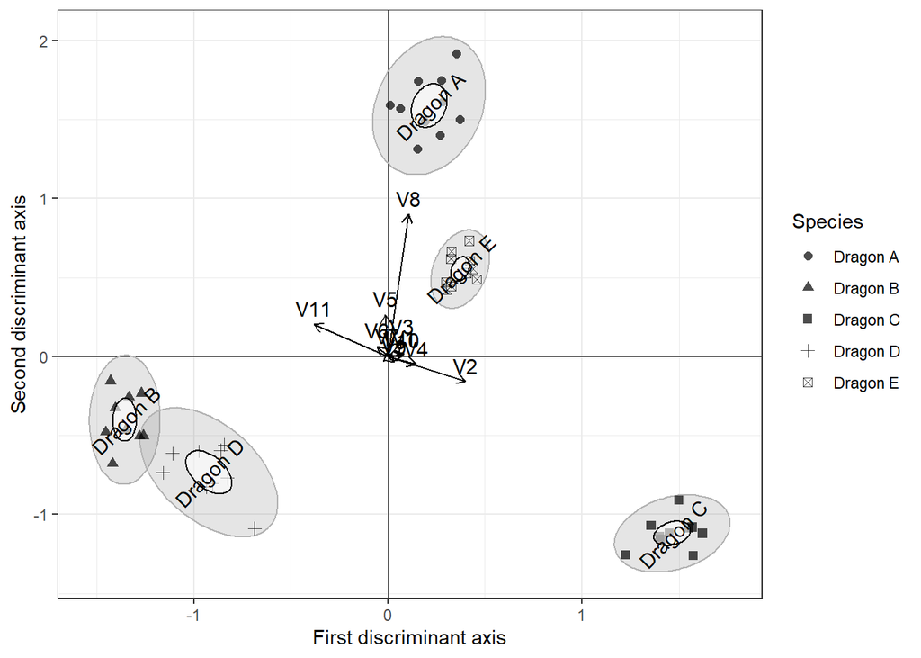

```r
source("https://raw.githubusercontent.com/essicolo/AgFun/master/plotDA_gg.R")
plotDA(scores = dragon_lda$li,
       loadings = dragon_lda$fa,
       fac = as.factor(dragons_final$Species),
       level=0.95,
       facname = "Species",
       propLoadings = 1)
```

Le premier axe discriminant classe les espèces dans 3 groupes différents. Le premier groupe est formé par les espèces *B* et *D* (même s’il existe des différences entre elles), le deuxième groupe est composé des espèces *A* et *E* et le troisième est composé juste pour *Dragon C*. Les différences dans le premier discriminant sont expliquées notamment par les variables V2 et V11, dont les « loadings » pour cet axe sont ~ 0.40 et ~ -0.38, respectivement. Par rapport au deuxième axe discriminant toutes les espèces présentent différences, malgré que les espèces de dragon *C*, *D* et *B* semblent être plus proches. Les différences sur cet axe s’expliquent principalement par la variable *V8*, dont le « loading » est ~ 0.90.

# *Conclusion*

Techniques multivariées d’imputation de données manquantes et données aberrantes ont été appliquées. 18% des individus étudiés avaient données manquantes au début de l’analyse des données, lesquelles ont été imputées. Les données aberrantes ont été détectées en regroupant les individus par espèce, ainsi, la méthode de détection de valeurs anormales a détecté 8 individus qui contenaient certaines de ces valeurs. Étant donné que ceux-ci représentaient le 16 % de l’ensemble des individus, seuls deux ont été supprimés et les valeurs aberrantes des autres ont été corrigées. Enfin, l’analyse discriminante linéaire a trouvé des différences entre les espèces, lesquelles peuvent être expliquées avec les deux premiers axes discriminants.